# Casualties and Economic Impact of Weather Events Across the US

13/11/2020

# Synopsis

The data from 1950 to 2011 is analyzed to find out what types of weather events are the most harmful to the population and what types are the most costly across the US. The data is extracted from the National Oceanic and Atmospheric Administration’S (NOAA) data base. The analysis show that tornadoes are the most harmful to the US population in term of both fatalities and injuries. Floods are the most costly.

# Data processing

The data is downloaded from the following website: [data](https://d396qusza40orc.cloudfront.net/repdata%2Fdata%2FStormData.csv.bz2)

Check out source [1](https://d396qusza40orc.cloudfront.net/repdata%2Fpeer2_doc%2Fpd01016005curr.pdf) and [2](https://d396qusza40orc.cloudfront.net/repdata%2Fpeer2_doc%2FNCDC%20Storm%20Events-FAQ%20Page.pdf) for information about the data set.

The data set is loaded and the dates are converted to the right format to make the analysis easier.

```r
## Loading the libraries needed for the analysis
library(dplyr)
library(ggplot2)
library(tidyr)
```

```r
## Download the data
fileURL <- "https://d396qusza40orc.cloudfront.net/repdata%2Fdata%2FStormData.csv.bz2"
download.file(fileURL, "Data_asgn2.csv.bz2", method = "curl")

## Extract the data from the zip file
DT <- read.csv("Data_asgn2.csv.bz2")

## Dates are stored in dates format ignoring the time
DT$BGN_DATE <- as.Date(DT$BGN_DATE, format = "%m/%d/%Y")

## Find out which events occurred the most and select the top 10
tt <- table(DT$EVTYPE)
max_tt <- as.data.frame(sort(tt, decreasing = TRUE)[1:10])
names(max_tt) <- c("Event_type","Occurences")
```

Here are a few interesting information about the data set:

- Number of observations : 902297
- Data is collected from 1950-01-03 to 2011-11-30
- Data is collected across 72 states
- The data set records a total of 985 different weather events
- Total number of fatalities recorded : 15145
- Total number of injuries recorded : 140528
- The top 10 occurrences in term of weather events recorded is as follow:

```r
knitr::kable(max_tt)
```

| Event_type | Occurences |
| --- | --- |
| HAIL | 288661 |
| TSTM WIND | 219940 |
| THUNDERSTORM WIND | 82563 |
| TORNADO | 60652 |
| FLASH FLOOD | 54277 |
| FLOOD | 25326 |
| THUNDERSTORM WINDS | 20843 |
| HIGH WIND | 20212 |
| LIGHTNING | 15754 |
| HEAVY SNOW | 15708 |

# Results

## Weather events - casualties

In this section the number of death per type of event is presented.

```r
## Group the number of death per type of event and calculate the total number of death
DT_FAT <- DT %>% group_by(EVTYPE) %>% summarize(FATALITIES = sum(FATALITIES))

## Group the number of death per type of event and calculate the total number of injuries
DT_INJ <- DT %>% group_by(EVTYPE) %>% summarize(INJURIES = sum(INJURIES))

## Extract the top 10 most harmful events
DT_FAT_10 <- head(arrange(DT_FAT, desc(FATALITIES)),10)
DT_INJ_10 <- head(arrange(DT_INJ, desc(INJURIES)),10)

## Calculate the total number of other fatalities and injuries caused by the rest of these events
DT_FAT_10 <- rbind(DT_FAT_10, c("Other events", sum(DT$FATALITIES)-sum(DT_FAT_10$FATALITIES)))
DT_INJ_10 <- rbind(DT_INJ_10, c("Other events", sum(DT$INJURIES)-sum(DT_INJ_10$INJURIES)))

## Clean the data set
names(DT_FAT_10) <- c("EVTYPE","NUMBER")
names(DT_INJ_10) <- c("EVTYPE","NUMBER")
DT_FAT_10$NUMBER <- as.numeric(DT_FAT_10$NUMBER)
DT_INJ_10$NUMBER <- as.numeric(DT_INJ_10$NUMBER)

## Plot the results on a bar chart
g1 <- ggplot(DT_FAT_10, aes(x= reorder(EVTYPE, -NUMBER),y = NUMBER)) + geom_bar(stat = "identity", alpha = .5) + labs(title = paste("Weather events fatalities in the US from",min(DT$BGN_DATE), "to", max(DT$BGN_DATE)), x = "Event Type", y = "Number of fatalities", caption = "Source : NOAA") + theme(axis.text.x = element_text(angle = 90)) + geom_text(aes(label = NUMBER))

g2 <- ggplot(DT_INJ_10, aes(x= reorder(EVTYPE, -NUMBER),y = NUMBER)) + geom_bar(stat = "identity", alpha = .5) + labs(title = paste("Weather events injuries in the US from",min(DT$BGN_DATE), "to", max(DT$BGN_DATE)), x = "Event Type", y = "Number of injuries", caption = "Source : NOAA") + theme(axis.text.x = element_text(angle = 90)) + coord_cartesian(ylim=c(0,11000)) +  geom_text(y = 10000, aes(label = NUMBER), angle = 30)
```

The graphs below show the top 10 events most harmful to the population (fatalities and injuries):

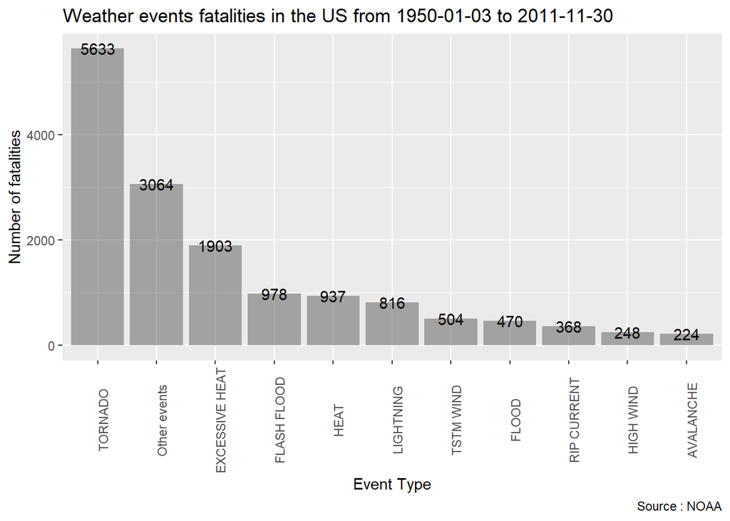

```r
g1
```

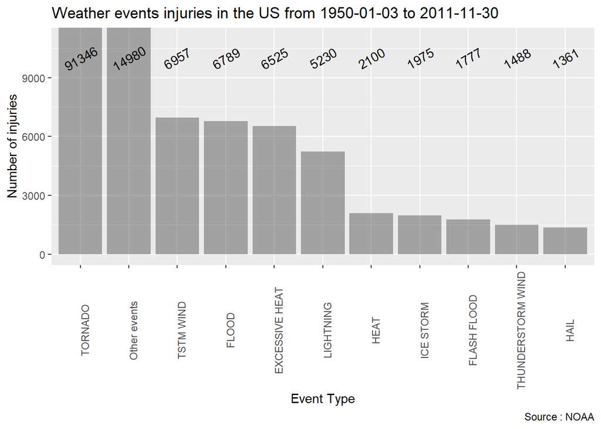

```r
g2
```

To find the data including all the other events, please refer to the appendix section.

**Tornadoes are by far the most harmful events in term of both fatalities and injuries.**

## Weather event - Economic consequences

In this section the economic consequences of weather events is presented. Damages are evaluated using two parameters, the property damage and the crop damage. Both of them are presented below.

```r
## Create a subset vector containing only the damage data
DT_Dam <- select(DT,EVTYPE,PROPDMG,PROPDMGEXP,CROPDMG,CROPDMGEXP)

## Create a function that calculates the total damage by using the exponent
Calc_dam <- function(x, exp){
    tot <- rep(0,length(x))
    x[is.na(x)] <- 0 ## if the exponent is missing, return 0
    tot[exp == "K"] <- x[exp == "K"]*1000
    tot[exp == "M"] <- x[exp == "M"]*1000000
    tot[exp == "B"] <- x[exp == "B"]*1000000000
    tot
}

## Calculate the total damage for each type of damage and calculate the sum of the two
DT_Dam$PROPDMGtot <- Calc_dam(DT_Dam$PROPDMG,DT_Dam$PROPDMGEXP)
DT_Dam$CROPDMGtot <- Calc_dam(DT_Dam$CROPDMG,DT_Dam$CROPDMGEXP)
DT_Dam$DMGtot <- DT_Dam$PROPDMGtot + DT_Dam$CROPDMGtot

## Calculate the total amount of damage per type of event
Dam_Prop <- DT_Dam %>% group_by(EVTYPE) %>% summarize(Damage = sum(PROPDMGtot))
Dam_Crop <- DT_Dam %>% group_by(EVTYPE) %>% summarize(Damage = sum(CROPDMGtot))
Dam_tot <- DT_Dam %>% group_by(EVTYPE) %>% summarize(Damage = sum(DMGtot))

## Retrieve the top 10 most damaging type of events
Dam_tot_10 <- head(arrange(Dam_tot, desc(Damage)),10)

## For these 10 variables calculate the damages due to property damage and crop damage
for (i in 1:10){
    Dam_tot_10$prop[i] <- Dam_Prop$Damage[Dam_Prop$EVTYPE == Dam_tot_10$EVTYPE[i]]
    Dam_tot_10$crop[i] <- Dam_Crop$Damage[Dam_Crop$EVTYPE == Dam_tot_10$EVTYPE[i]]
}

## Calculate the total damage caused by the rest of these events
Dam_tot_10 <- rbind(Dam_tot_10, c("Other events", sum(DT_Dam$DMGtot)-sum(Dam_tot_10$Damage),sum(Dam_Prop$Damage)-sum(Dam_tot_10$prop),sum(Dam_Crop$Damage)-sum(Dam_tot_10$crop)))

## Convert to numerical values and set scale in billions of dollars
Dam_tot_10$Damage <- as.numeric(Dam_tot_10$Damage)/1E9
Dam_tot_10$prop <- as.numeric(Dam_tot_10$prop)/1E9
Dam_tot_10$crop <- as.numeric(Dam_tot_10$crop)/1E9

## Create a data frame usable for the bar chart
Dam_graph <- select(Dam_tot_10,-Damage) %>% gather("DamageType", "Amount", -EVTYPE)

## Plot the results on a bar chart
g3 <- ggplot(Dam_graph, aes(x = reorder(EVTYPE,-Amount), y = Amount, fill = DamageType)) + geom_bar(stat = "identity", alpha = .5) + labs(title = paste("Economic consequences of weather events in the US from",min(DT$BGN_DATE), "to", max(DT$BGN_DATE)), x = "Event Type", y = "Cost [billions of USD]", caption = "Source : NOAA") + theme(axis.text.x = element_text(angle = 90), plot.title = element_text(size = 9)) + coord_flip()
```

The graph below shows the economic consequences for the top 10 most costly weather events. Note that the cost is expressed in billions of dollars. More details are presented in appendix.

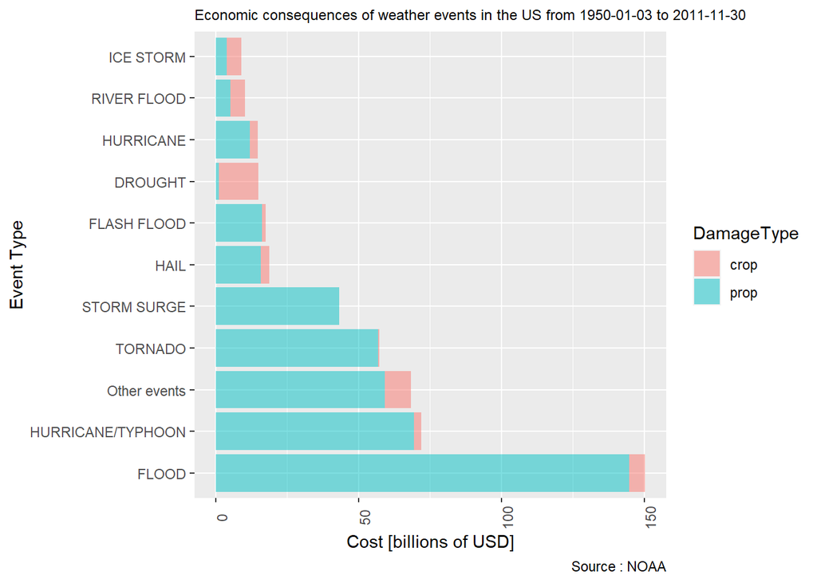

```r
g3
```

**Floods are by far the most costly weather event in term of economic consequences. Hurricane/Typhoons, tornadoes and storm surges are also very costly. Note that for most of the weather events the property damage cost is predominant compared to crop damage cost.** This is not always the case though (ex: Drought events).

# Appendix

## Fatalities per weather event

```r
DT_FAT_t <- subset(DT_FAT, FATALITIES>10)
knitr::kable(arrange(DT_FAT_t, desc(FATALITIES)))
```

| EVTYPE | FATALITIES |
| --- | --- |
| TORNADO | 5633 |
| EXCESSIVE HEAT | 1903 |
| FLASH FLOOD | 978 |
| HEAT | 937 |
| LIGHTNING | 816 |
| TSTM WIND | 504 |
| FLOOD | 470 |
| RIP CURRENT | 368 |
| HIGH WIND | 248 |
| AVALANCHE | 224 |
| WINTER STORM | 206 |
| RIP CURRENTS | 204 |
| HEAT WAVE | 172 |
| EXTREME COLD | 160 |
| THUNDERSTORM WIND | 133 |
| HEAVY SNOW | 127 |
| EXTREME COLD/WIND CHILL | 125 |
| STRONG WIND | 103 |
| BLIZZARD | 101 |
| HIGH SURF | 101 |
| HEAVY RAIN | 98 |
| EXTREME HEAT | 96 |
| COLD/WIND CHILL | 95 |
| ICE STORM | 89 |
| WILDFIRE | 75 |
| HURRICANE/TYPHOON | 64 |
| THUNDERSTORM WINDS | 64 |
| FOG | 62 |
| HURRICANE | 61 |
| TROPICAL STORM | 58 |
| HEAVY SURF/HIGH SURF | 42 |
| LANDSLIDE | 38 |
| COLD | 35 |
| HIGH WINDS | 35 |
| TSUNAMI | 33 |
| WINTER WEATHER | 33 |
| UNSEASONABLY WARM AND DRY | 29 |
| URBAN/SML STREAM FLD | 28 |
| WINTER WEATHER/MIX | 28 |
| TORNADOES, TSTM WIND, HAIL | 25 |
| WIND | 23 |
| DUST STORM | 22 |
| FLASH FLOODING | 19 |
| DENSE FOG | 18 |
| EXTREME WINDCHILL | 17 |
| FLOOD/FLASH FLOOD | 17 |
| RECORD/EXCESSIVE HEAT | 17 |
| HAIL | 15 |
| COLD AND SNOW | 14 |
| FLASH FLOOD/FLOOD | 14 |
| MARINE STRONG WIND | 14 |
| STORM SURGE | 13 |
| WILD/FOREST FIRE | 12 |
| STORM SURGE/TIDE | 11 |
| UNSEASONABLY WARM | 11 |

## Injuries per weather event

```r
DT_INJ_t <- subset(DT_INJ, INJURIES>10)
knitr::kable(arrange(DT_INJ_t, desc(INJURIES)))
```

| EVTYPE | INJURIES |
| --- | --- |
| TORNADO | 91346 |
| TSTM WIND | 6957 |
| FLOOD | 6789 |
| EXCESSIVE HEAT | 6525 |
| LIGHTNING | 5230 |
| HEAT | 2100 |
| ICE STORM | 1975 |
| FLASH FLOOD | 1777 |
| THUNDERSTORM WIND | 1488 |
| HAIL | 1361 |
| WINTER STORM | 1321 |
| HURRICANE/TYPHOON | 1275 |
| HIGH WIND | 1137 |
| HEAVY SNOW | 1021 |
| WILDFIRE | 911 |
| THUNDERSTORM WINDS | 908 |
| BLIZZARD | 805 |
| FOG | 734 |
| WILD/FOREST FIRE | 545 |
| DUST STORM | 440 |
| WINTER WEATHER | 398 |
| DENSE FOG | 342 |
| TROPICAL STORM | 340 |
| HEAT WAVE | 309 |
| HIGH WINDS | 302 |
| RIP CURRENTS | 297 |
| STRONG WIND | 280 |
| HEAVY RAIN | 251 |
| RIP CURRENT | 232 |
| EXTREME COLD | 231 |

[output cut: 51 more lines]

## Economical consequences per weather event

```r
## Create a data set containing all economic costs
DT_cost <- merge(x = Dam_Prop, y = Dam_Crop, by = "EVTYPE")
names(DT_cost) <- c("EVTYPE","Property_Damage", "Crop_Damage")
DT_cost$Total_Cost <- DT_cost$Property_Damage + DT_cost$Crop_Damage

## Convert numbers to billions of dollars
DT_cost <- DT_cost %>% mutate(Property_Damage = Property_Damage/1E9, Crop_Damage = Crop_Damage/1E9, Total_Cost = Total_Cost/1E9)

## Extract and print only the weather events that cost more than 1,000,000 USD
DT_display <- subset(DT_cost, DT_cost$Total_Cost > 0.1)
knitr::kable(arrange(DT_display,desc(Total_Cost)))
```

| EVTYPE | Property_Damage | Crop_Damage | Total_Cost |
| --- | --- | --- | --- |
| FLOOD | 144.6577098 | 5.6619684 | 150.3196783 |
| HURRICANE/TYPHOON | 69.3058400 | 2.6078728 | 71.9137128 |
| TORNADO | 56.9256605 | 0.4149531 | 57.3406136 |
| STORM SURGE | 43.3235360 | 0.0000050 | 43.3235410 |
| HAIL | 15.7273667 | 3.0255374 | 18.7529042 |
| FLASH FLOOD | 16.1408115 | 1.4213171 | 17.5621286 |
| DROUGHT | 1.0461060 | 13.9725660 | 15.0186720 |
| HURRICANE | 11.8683190 | 2.7419100 | 14.6102290 |
| RIVER FLOOD | 5.1189455 | 5.0294590 | 10.1484045 |
| ICE STORM | 3.9449278 | 5.0221135 | 8.9670413 |
| TROPICAL STORM | 7.7038905 | 0.6783460 | 8.3822366 |
| WINTER STORM | 6.6884973 | 0.0269440 | 6.7154412 |
| HIGH WIND | 5.2700463 | 0.6385713 | 5.9086176 |
| WILDFIRE | 4.7651140 | 0.2954728 | 5.0605868 |
| TSTM WIND | 4.4849284 | 0.5540074 | 5.0389358 |
| STORM SURGE/TIDE | 4.6411880 | 0.0008500 | 4.6420380 |
| THUNDERSTORM WIND | 3.4831211 | 0.4148430 | 3.8979642 |
| HURRICANE OPAL | 3.1528460 | 0.0090000 | 3.1618460 |
| WILD/FOREST FIRE | 3.0018295 | 0.1067968 | 3.1086263 |
| HEAVY RAIN/SEVERE WEATHER | 2.5000000 | 0.0000000 | 2.5000000 |
| THUNDERSTORM WINDS | 1.7334528 | 0.1906507 | 1.9241036 |
| TORNADOES, TSTM WIND, HAIL | 1.6000000 | 0.0025000 | 1.6025000 |
| HEAVY RAIN | 0.6942481 | 0.7333998 | 1.4276479 |
| EXTREME COLD | 0.0677374 | 1.2929730 | 1.3607104 |
| SEVERE THUNDERSTORM | 1.2053600 | 0.0002000 | 1.2055600 |
| FROST/FREEZE | 0.0094800 | 1.0940860 | 1.1035660 |
| HEAVY SNOW | 0.9325891 | 0.1346531 | 1.0672422 |
| LIGHTNING | 0.9286593 | 0.0120921 | 0.9407514 |
| BLIZZARD | 0.6592140 | 0.1120600 | 0.7712740 |
| HIGH WINDS | 0.6083236 | 0.0407206 | 0.6490442 |
| WILD FIRES | 0.6241000 | 0.0000000 | 0.6241000 |
| TYPHOON | 0.6002300 | 0.0008250 | 0.6010550 |
| EXCESSIVE HEAT | 0.0077537 | 0.4924020 | 0.5001557 |
| FREEZE | 0.0002050 | 0.4462250 | 0.4464300 |
| HEAT | 0.0017970 | 0.4014615 | 0.4032585 |
| HURRICANE ERIN | 0.2581000 | 0.1360100 | 0.3941100 |
| LANDSLIDE | 0.3245960 | 0.0200170 | 0.3446130 |
| FLASH FLOODING | 0.3077636 | 0.0151060 | 0.3228697 |
| FLASH FLOOD/FLOOD | 0.2724500 | 0.0005550 | 0.2730050 |
| DAMAGING FREEZE | 0.0080000 | 0.2621000 | 0.2701000 |
| FLOOD/FLASH FLOOD | 0.1740390 | 0.0950340 | 0.2690730 |
| HAILSTORM | 0.2410000 | 0.0000000 | 0.2410000 |
| STRONG WIND | 0.1752414 | 0.0649535 | 0.2401950 |
| COASTAL FLOOD | 0.2376656 | 0.0000000 | 0.2376656 |
| TSUNAMI | 0.1440620 | 0.0000200 | 0.1440820 |
| EXCESSIVE WETNESS | 0.0000000 | 0.1420000 | 0.1420000 |
| River Flooding | 0.1061550 | 0.0280200 | 0.1341750 |
| COASTAL FLOODING | 0.1266405 | 0.0000560 | 0.1266965 |
| HIGH WINDS/COLD | 0.1105000 | 0.0070000 | 0.1175000 |
| FLOODING | 0.1082550 | 0.0088555 | 0.1171105 |
| FLOOD/RAIN/WINDS | 0.0000000 | 0.1128000 | 0.1128000 |
| HURRICANE OPAL/HIGH WINDS | 0.1000000 | 0.0100000 | 0.1100000 |
| TSTM WIND/HAIL | 0.0443355 | 0.0646962 | 0.1090318 |
| MAJOR FLOOD | 0.1050000 | 0.0000000 | 0.1050000 |
| WILDFIRES | 0.1005000 | 0.0005000 | 0.1010000 |